# Global root traits (GRooT) database - Guerrero‐Ramírez - - Global Ecology and Biogeography - Wiley Online Library

DATA PAPER

Open Access

# Global root traits (GRooT) database

[Nathaly R. Guerrero‐Ramírez](https://onlinelibrary.wiley.com/action/doSearch?ContribAuthorStored=Guerrero-Ram%C3%ADrez%2C+Nathaly+R)

[Liesje Mommer](https://onlinelibrary.wiley.com/action/doSearch?ContribAuthorStored=Mommer%2C+Liesje)

[Grégoire T. Freschet](https://onlinelibrary.wiley.com/action/doSearch?ContribAuthorStored=Freschet%2C+Gr%C3%A9goire+T)

[Colleen M. Iversen](https://onlinelibrary.wiley.com/action/doSearch?ContribAuthorStored=Iversen%2C+Colleen+M)

[M. Luke McCormack](https://onlinelibrary.wiley.com/action/doSearch?ContribAuthorStored=McCormack%2C+M+Luke)

[Jens Kattge](https://onlinelibrary.wiley.com/action/doSearch?ContribAuthorStored=Kattge%2C+Jens)

[Hendrik Poorter](https://onlinelibrary.wiley.com/action/doSearch?ContribAuthorStored=Poorter%2C+Hendrik)

[Fons van der Plas](https://onlinelibrary.wiley.com/action/doSearch?ContribAuthorStored=Plas%2C+Fons)

[Joana Bergmann](https://onlinelibrary.wiley.com/action/doSearch?ContribAuthorStored=Bergmann%2C+Joana)

… See all authors

First published: 09 September 2020

https://doi.org/10.1111/geb.13179

## Abstract

### Motivation

Trait data are fundamental to the quantitative description of plant form and function. Although root traits capture key dimensions related to plant responses to changing environmental conditions and effects on ecosystem processes, they have rarely been included in large‐scale comparative studies and global models. For instance, root traits remain absent from nearly all studies that define the global spectrum of plant form and function. Thus, to overcome conceptual and methodological roadblocks preventing a widespread integration of root trait data into large‐scale analyses we created the Global Root Trait (GRooT) Database. GRooT provides ready‐to‐use data by combining the expertise of root ecologists with data mobilization and curation. Specifically, we (a) determined a set of core root traits relevant to the description of plant form and function based on an assessment by experts, (b) maximized species coverage through data standardization within and among traits, and (c) implemented data quality checks.

### Main types of variables contained

GRooT contains 114,222 trait records on 38 continuous root traits.

### Spatial location and grain

Global coverage with data from arid, continental, polar, temperate and tropical biomes. Data on root traits were derived from experimental studies and field studies.

### Time period and grain

Data were recorded between 1911 and 2019.

### Major taxa and level of measurement

GRooT includes root trait data for which taxonomic information is available. Trait records vary in their taxonomic resolution, with subspecies or varieties being the highest and genera the lowest taxonomic resolution available. It contains information for 184 subspecies or varieties, 6,214 species, 1,967 genera and 254 families. Owing to variation in data sources, trait records in the database include both individual observations and mean values.

### Software format

GRooT includes two csv files. A GitHub repository contains the csv files and a script in R to query the database.

## 1 INTRODUCTION

Plant traits have been used for describing multiple aspects of plant species’ fitness and realized performance, including growth, survival and reproduction (Adler et al., 2014; Calow, 1987; Díaz et al., 2016; Geber & Griffen, 2003; Grime, 1977; Reich et al., 2003). Moreover, traits can illustrate how species respond to environmental variability and disturbances (Bruelheide et al., 2018; Grime, 1974; Keddy, 1992; Minden & Olde Venterink, 2019; Pausas et al., 2004; Wieczynski et al., 2019) and reveal species effects on ecosystem functions (Breitschwerdt et al., 2018; Craven et al., 2018; Díaz & Cabido, 2001; Lavorel & Garnier, 2002). Although root traits are likely to capture key dimensions of plant form and function, plant evolutionary history and responses to environmental variability (Bardgett et al., 2014; Freschet et al., 2017; Kong et al., 2019; Laliberté, 2016; Ma et al., 2018; Valverde‐Barrantes et al., 2017), they remain underrepresented in large‐scale comparative studies and global models. Accordingly, root traits remain absent from nearly all existing studies that define the global spectrum of plant form and function (Chave et al., 2009; Díaz et al., 2016; Reich, 2014; Wright et al., 2004; but see Averill et al., 2019).

Conceptual and methodological challenges have deterred widespread data integration of root traits into global trait databases. Conceptually, the functional importance of some root traits has yet to be established formally, which might preclude their use in large‐scale analyses (Aubin et al., 2016). Methodologically, quantificatio of root traits is labour intensive, and there are technical difficulties in obtaining accurate measurements (e.g., Delory et al., 2017). Furthermore, large variation in methodologies precludes data standardization and integration within traits. Specifically, although traits are characteristics measurable at the level of the individual plant (Violle et al., 2007), root traits can be measured in different ways, increasing the number of trait variables. For example, data for root nitrogen uptake are separated into eight trait variables (Iversen et al., 2017). Although coordinated initiatives, such as the Fine‐Root Ecology Database (FRED; Iversen et al., 2017) and the Plant Trait Database (TRY; Kattge et al., 2011, 2020), have compiled valuable root trait data, these databases still face many of these conceptual and methodological challenges associated with root traits.

FRED has been essential in terms of mobilization of fine‐root trait data and is the largest contributor of root trait data to TRY (Kattge et al., 2020). FRED contains ~300 root trait variables; this high resolution of root variables allows users to investigate a broad set of research questions. However, barriers remain when using these root trait data in the context of large‐scale comparative studies. For example, the number of trait variables can be overwhelming, particularly for non‐root specialists. Furthermore, a large number of trait variables have few data records, limiting data‐quality checks. For example, TRY performs data standardization and intensive data‐quality checks for traits with > 1,000 records (Kattge et al., 2020), but most root traits have fewer records than this threshold. In addition, some trait variables that are not directly comparable in terms of definitions and units have been aggregated by type on TRY, such as root type/root architecture. Therefore, using these data requires that one first disaggregates these traits (e.g., by establishing links between trait names and definitions) and then standardizes trait values. Finally, accurate global assessments on root trait data availability, in terms of geographical or phylogenetic coverage, are essential to identify data gaps and to work towards increasing representativeness in large‐scale comparative studies and dynamic global vegetation models.

To overcome these roadblocks, we have created the Global Root Trait (GRooT) Database. The main objective of GRooT is to make root trait data ready to use, particularly in the context of large‐scale analyses. To do so, we first provide a set of core root traits that are considered to be relevant for describing plant form and function. Trait selection builds on the compilation of standardized trait measurements in a new handbook on root traits (Freschet et al., 2020) and an assessment by experts on root traits. In addition, we improve data coverage by compiling information from existing databases, mobilizing new data and standardizing data across methodologies within and among traits. Furthermore, we curate and perform data quality checks for each root trait in GRooT and make these data publicly available. Secondly, we provide within GRooT a unique overview of global root trait availability in terms of geographical and phylogenetic coverage. We envision that our advanced root trait database will be informative to global trait‐based models and help to guide future measurement initiatives.

## 2 METHODS

### 2.1 Data acquisition and compilation

GRooT includes root trait data provided directly from researchers, extracted from literature, or from large databases, such as FRED v.2.3 (https://roots.ornl.gov/; Iversen et al., 2017, 2018) and TRY v.4.1 ([https://www.try‐db.org](https://www.try-db.org/); Kattge et al., 2011, 2020). In total, GRooT includes data from 919 publications via FRED, 38 datasets via TRY and 12 additional datasets (Appendix 1, Data References).

GRooT was assembled by initially determining which root traits are most relevant in terms of describing plant form and function (Table 1; Supporting Information Tables S1 and S2). To build towards an ontology of root traits, we standardized trait names across data sources (Supporting Information Table S3) and matched them with names from the new handbook of root traits (Freschet et al., 2020). Subsequently, we checked available trait variables (> 700) to establish: (a) which variable was associated with preselected root traits relevant to the description of plant form and function; (b) which variables would be the most pertinent for each root trait in terms of available methodologies, standardized definitions and units, which were based mostly on the handbook of root traits (Freschet et al., 2020); and (c) which variables could be standardized across methodologies within or among traits. Within traits, we aggregated comparable trait variables into a single unique trait (e.g., specific root respiration was combined into a unique trait, independent of it being measured as O<sub>2</sub> consumption or CO<sub>2</sub> release; Supporting Information Table S3). Among traits, we recalculated values for traits that could be standardized, such as: (a) data on the root‐to‐shoot ratio for the calculation of root mass fraction (RMF); and (b) data on stele diameter for the calculation of the stele fraction (Supporting Information Table S3; Figure S1). After this process, we retained those relevant traits with data for > 50 plant species in the database (Table 1), because traits with lower species coverage seemed less helpful for large‐scale analyses involving many species. Traits below this threshold, but still relevant, are currently excluded from GRooT (Supporting Information Table S2).

TABLE 1. Root traits included in GRooT

| Trait | Units | Number of species | Number of Species by site | Mean | Quantile (.25) | Median | Quantile (.75) |
| --- | --- | --- | --- | --- | --- | --- | --- |
| *Anatomy* |  |  |  |  |  |  |  |
| Root cortex thickness | μm | 151 | 180 | 207.8 | 76.9 | 153.2 | 300.4 |
| Root stele diameter | μm | 318 | 491 | 185.9 | 57.9 | 104.1 | 204.4 |
| Root stele fraction | % | 352 | 534 | 0.13 | 0.05 | 0.08 | 0.15 |
| Root xylem vessel number<sup>a</sup> | number/mm<sup>2</sup> | 96 | 97 | 4,438 | 2,325 | 3,828 | 5,847 |
| Root vessel diameter<sup>a</sup> | μm | 125 | 125 | 9.2 | 4.2 | 6.5 | 9.1 |
| *Architecture* |  |  |  |  |  |  |  |
| Root branching ratio | number/number | 173 | 189 | 3.52 | 2.45 | 3.12 | 4.30 |
| Root branching density<sup>b</sup> | number/cm | 216 | 247 | 2.79 | 1.62 | 2.17 | 3.35 |
| Belowground allocation |  |  |  |  |  |  |  |
| Root mass fraction | g/g | 1,348 | 3,527 | 0.40 | 0.24 | 0.36 | 0.54 |
| *Chemistry* |  |  |  |  |  |  |  |
| Root structural carbohydrate concentration | mg/g | 185 | 228 | 567.9 | 443.1 | 620.0 | 692.6 |
| Root lignin concentration | mg/g | 311 | 401 | 164.2 | 96.5 | 153.5 | 203.2 |
| Root carbon concentration | mg/g | 1,099 | 2,328 | 417.3 | 388.2 | 416.7 | 455.5 |
| Root nitrogen concentration | mg/g | 1,719 | 3,619 | 12.5 | 7.8 | 10.8 | 15.5 |
| Root phosphorus concentration | mg/g | 486 | 1,284 | 1.33 | 0.74 | 1.10 | 1.61 |
| Root carbon‐to‐nitrogen ratio | mg/mg | 925 | 1,308 | 41.6 | 25.3 | 35.8 | 51.5 |
| Root nitrogen‐to‐phosphorus ratio | mg/mg | 154 | 154 | 13.7 | 6.0 | 10.6 | 19.0 |
| Root calcium concentration | mg/g | 169 | 915 | 5.10 | 2.44 | 3.38 | 5.57 |
| Root potassium concentration | mg/g | 167 | 891 | 6.88 | 3.65 | 5.95 | 8.92 |
| Root magnesium concentration | mg/g | 146 | 862 | 2.55 | 1.39 | 2.09 | 3.27 |
| Root manganese concentration | mg/g | 52 | 89 | 0.22 | 0.10 | 0.16 | 0.29 |
| *Dynamics and decomposition* |  |  |  |  |  |  |  |
| Root production<sup>c</sup> | g/m<sup>2</sup>/year | 116 | 201 | 397.5 | 116.6 | 230.0 | 436.8 |
| Root lifespan mean | days | 80 | 98 | 696.2 | 252.5 | 377.0 | 734.5 |
| Root lifespan median | days | 60 | 65 | 324.8 | 149.5 | 255.7 | 357.9 |
| Root turnover rate | /year | 126 | 251 | 0.79 | 0.21 | 0.55 | 1.04 |
| Root litter mass loss rate | /year | 232 | 289 | 1.92 | 0.27 | 0.67 | 2.51 |
| *Horizontal plant mobility* |  |  |  |  |  |  |  |
| Lateral spread<sup>d</sup> | cm/year | 1,398 | 1,398 | 7.92 | 0.50 | 6.80 | 13.0 |
| *Microbial associations* <sup>e</sup> |  |  |  |  |  |  |  |
| Root mycorrhizal colonization intensity<sup>f</sup> | % | 2,405 | 2,529 | 40.5 | 9.4 | 40.0 | 64.5 |
| *Morphology* |  |  |  |  |  |  |  |
| Mean root diameter | mm | 1,628 | 2,845 | 0.44 | 0.22 | 0.36 | 0.55 |
| Root dry matter content | g/g<sup>1</sup> | 431 | 1,499 | 0.22 | 0.15 | 0.22 | 0.28 |
| Root tissue density | g/cm<sup>3</sup> | 1,465 | 3,291 | 0.25 | 0.11 | 0.20 | 0.34 |
| Specific root area | cm<sup>2</sup>/g | 477 | 707 | 617.7 | 179.1 | 385.8 | 728.4 |
| Specific root length | m/g | 1,973 | 3,407 | 88.7 | 18.9 | 47.4 | 113.0 |
| *Physiology and respiration* |  |  |  |  |  |  |  |
| Net uptake rate of nitrogen | µmol/g/day | 68 | 68 | 49.5 | 32.3 | 52.6 | 64.8 |
| Specific root respiration | nmol/g/s | 248 | 408 | 21.7 | 7.0 | 14.6 | 32.7 |
| *System and distribution* |  |  |  |  |  |  |  |
| Fine root mass‐to‐leaf mass ratio | g/g | 143 | 176 | 2.39 | 0.08 | 0.32 | 2.30 |
| Coarse‐to‐fine root mass ratio | g/g | 128 | 130 | 10.6 | 1.7 | 5.0 | 12.8 |
| Root mass density | g/cm<sup>3</sup> | 152 | 260 | 0.13 | 0.0001 | 0.02 | 0.13 |
| Root length density | cm/cm<sup>3</sup> | 122 | 178 | 4.10 | 0.43 | 1.82 | 5.80 |
| Maximum rooting depth | m | 1,024 | 1,782 | 2.21 | 0.50 | 1.10 | 2.00 |

- For each trait, standardized units, number of species and number of species‐by‐site mean values are presented. Traits are categorized based on McCormack et al. (2017) and Freschet et al. (2020). See the Supporting Information (Table S1) for trait definitions.
- <sup>a</sup> This information can be used to calculate theoretical root specific hydraulic conductance (Valenzuela‐Estrada et al., 2009).
- <sup>b</sup> This information needs to be interpreted with caution, because the included total root length can vary across studies.
- <sup>c</sup> This trait can be measured via minirhizotrons or ingrowth cores, and both measurements lead to contrasting results.
- <sup>d</sup> Lateral spread by clonal growth; although this trait is not categorized as a trait of the root system per se, it was included because of its influence on root growth (Klimešová & Bello, 2009).
- <sup>e</sup> Qualitative microbial association traits, including mycorrhizal association type and nitrogen‐fixing capacity, are included in GRooT (see Supporting Information Table S5).
- <sup>f</sup> Mycorrhizal colonization intensity is based mostly on data for arbuscular mycorrhizal colonization.

In GRooT, we included only trait records for which taxonomic information was available and excluded trait records where data was taken at the community level (i.e., from species mixtures). Trait records varied in their taxonomic resolution, with subspecies or varieties and genera being the highest and lowest taxonomic resolution available, respectively. We used the generic term of “root”, which includes any type of root entity (e.g., established using diameter cut‐offs, orders or functionality). Although the need to analyse root entities separately (e.g., separating between fine and coarse roots; root orders or diameter cut‐offs; or absorptive and transport roots) is generally recommended by a range of recent syntheses (Freschet & Roumet, 2017; McCormack et al., 2015), which entity is most suitable can vary greatly depending on the research question (Freschet & Roumet, 2017). Therefore, we have included information in GRooT that allows one to select data based on root entities (Supporting Information Table S4). We urge future data contributors to provide information about root entities and data users to consider this issue carefully.

GRooT includes selected meta‐data for each trait record, when available, such as taxonomic information, experimental conditions, sampling procedure, geographical location and date, in addition to climatic and soil variables (Supporting Information Table S5). Moreover, we have included additional information for each trait record, such as species growth form, photosynthetic pathway and woodiness (Supporting Information Table S5). We extracted this information from TRY and the Global Inventory of Floras and Traits (GIFT; http://gift.uni-goettingen.de/home; Weigelt et al., 2019) or from general Web research [e.g., Flora of China ([www.efloras.org](http://www.efloras.org/)), SEINet (swbiodiversity.org), United States Department of Agriculture (USDA; plants.usda.gov), and Southwest Desert Flora (southwestdesertflora.com)] when the information was not available in the aforementioned databases. We also included the present or absent ability to grow clonally and bud‐bearing information at the species level on GRooT based on the CLO‐PLA Database (CLO‐PLA; http://clopla.butbn.cas.cz/; Klimešová & Bello, 2009; Klimešová et al., 2017, 2019). For data collected in field conditions, biome classification according to Köppen–Geiger was included using the “kgc” R Package (Bryant et al., 2017).

We added information on qualitative root traits as mycorrhizal association type and nitrogen (N<sub>2</sub>)‐fixing capacity by interconnecting existing databases. For mycorrhizal type, we extracted data from the “FungalRoot: Global online database of plant mycorrhizal associations” (Soudzilovskaia et al., 2020). Mycorrhizal assignments were made at the genus level for plant species for which the mycorrhizal status is, according to current knowledge, conserved at this level (Soudzilovskaia et al., 2020). We included both standardized mycorrhizal types (named: mycorrhizalAssociationTypeFungalRoot) and mycorrhizal type from the original source (named: mycorrhizalAssociationType) in the database. For N<sub>2</sub>‐fixation capacity, we extracted data from the “Global database of plants with root‐symbiotic nitrogen fixation: NodDB Database” (v.1.3a; Tedersoo et al., 2018) at the genus level.

### 2.2 Data curation and quality control

We cross‐checked references associated with each dataset to avoid data redundancy, which was mostly generated by: (a) a dataset being submitted to multiple databases; or (b) databases including the dataset from different sources (e.g., submitted by the main authors versus extracted from literature, or the same data being used in multiple papers). When datasets or references appeared in multiple data sources, we performed manual checks to ensure the removal of redundant measurements while ensuring that complementary information was not removed. In some cases, data contributors were contacted directly to avoid dataset overlaps. Despite these efforts, there is the possibility that some redundant information remains in GRooT, which is most likely to be restricted to instances where data have been used in multiple publications.

GRooT contains original species names (as provided by the main source) and standardized species names. We standardized original species names using the Taxonomic Name Resolution Service v.4.0 (i.e., TNRS; http://tnrs.iplantcollaborative.org/; accessed September 2019; Boyle et al., 2013), selecting the best match among The Plant List v.1.1 (http://www.theplantlist.org/; accessed: 19 August 2015), Global Compositae Checklist (GCC; http://compositae.landcareresearch.co.nz/Default.aspx; accessed 21 August 2015), International Legume Database and Information Service (ILDIS; http://www.ildis.org/; accessed 21 August 2015), Missouri Botanical Garden’s Tropicos Database (http://www.tropicos.org; accessed 19 December 2014) and the USDA’s Plant Database (http://plants.usda.gov; accessed 17 January 2015). In addition, we obtained plant taxonomic order from the “taxize” R package v.0.9.4 (Chamberlain & Szöcs, 2013).

We checked trait records to ensure that data were in standardized units. Potential mistakes were checked in the original sources, corrected when possible or excluded when values were unreasonable (e.g., negative values for nutrient concentrations or percentages > 100). We calculated the error risk as the number of mean standard deviations (across all species within trait) from the respective species mean (named: errorRisk), following the TRY protocol (TRY; Kattge et al., 2011, 2020), but not implemented across root traits in TRY. We reported the number of data entries used to calculate the error risk per species (named: ErrorRiskEntries), with error risk robustness increasing when based on multiple replicates (preferably > 10 data entries). Normal distribution was checked for each trait, and logarithmic transformations were used before calculating error risk scores when required. Large error risk scores can indicate potential measurement errors, but they can also reflect intraspecific variation. Thus, we did not use error risk scores to remove trait records from the database but provide them to be used at the users’ discretion.

### 2.3 Data use guidelines and data availability

GRooT contains two csv files and an R script. The first csv file, named GRooTFullVersion.csv, provides root trait data at the highest resolution available (either trait values from individual replicates or mean values per study), information to filter data by entities (Supporting Information Table S4), meta‐data (Supporting Information Table S5) and error risk scores. The second file, named GRooTAggregateSpeciesVersion.csv, provides the mean, median and quantiles (.25 and .75) of species values. The R script, named GRooTExtraction, includes code to calculate error risk and the steps to calculate the mean, median and quantiles (.25 and .75) of species values. The code of the R script is customizable, including options to calculate mean values by excluding trait records based on the error risk, and to select data based on root entities (Supporting Information Table S4) or relevant covariables, such as root vitality (McCormack et al., 2015).

GRooT is publicly available but should be referenced by citing this paper. We suggest citing the original data sources that contributed a substantial proportion to the analysis. GRooT is located and will be maintained and updated in a GitHub repository ([https://groot‐database.github.io/GRooT/](https://groot-database.github.io/GRooT/)). We encourage users to report mistakes and suggestions to improve the database and to contribute data.

## 3 DESCRIPTION OF THE DATA

GRooT includes 38 root traits, with 38,276 species‐by‐site mean values based on 114,222 trait records (Table 1; Supporting Information Figures S2–S14). GRooT includes > 1,000 species with data on the following nine traits: root mass fraction, root carbon and nitrogen concentration, lateral spread, root mycorrhizal colonization intensity, mean root diameter, root tissue density, specific root length and maximum rooting depth. Data were collected in experimental microcosm studies (20.2 and 1.3% of species‐by‐site mean values from potted and hydroponic experiments, respectively) or field studies (71.4% of species‐by‐site mean values, including field observations and field or common garden experiments) or were unspecified (7.1% of species‐by‐site mean values). Root trait coverage from field studies varies geographically across the globe (Figure 1). Regions such as North America, Europe and Asia are well covered, whereas there are consistent gaps in other regions, such as Africa and South America. These geographical patterns are observed in terms of the number of species and the number of traits measured per site.

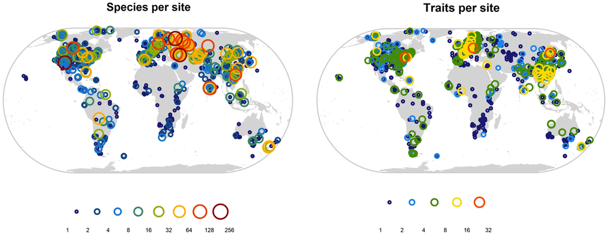

**FIGURE 1**

Maps depicting all geo‐referenced data from field studies included in the Global Root Trait (GRooT) Database. Circles indicate the range of species per site (e.g., one or two species, two to four species, successively) or traits per site (e.g., one or two traits, two to four traits, successively)

Phylogenetically, data in GRooT cover all major clades of vascular plants (i.e., pteridophytes, gymnosperms, basal angiosperms, monocots, magnoliids, basal eudicots, superrosids and superasterids; Figure 2a), with data for 254 families. However, phylogenetic gaps are observed for traits related to key categories, such as anatomy, architecture, dynamics and physiology. When accounting for the number of vascular species included in GRooT (*n* = 6,214 species across 254 families), the average number of traits per species within family ranges between two and 14, with an overall average of four traits for species across the phylogeny. When accounting for the number of vascular species accepted globally (based on The Plant List; *n* = 316,110 species across *n* = 442 families), the average number of traits per species within family ranges from zero to eight traits, with an overall average of less than one trait for species (Figure 2b).

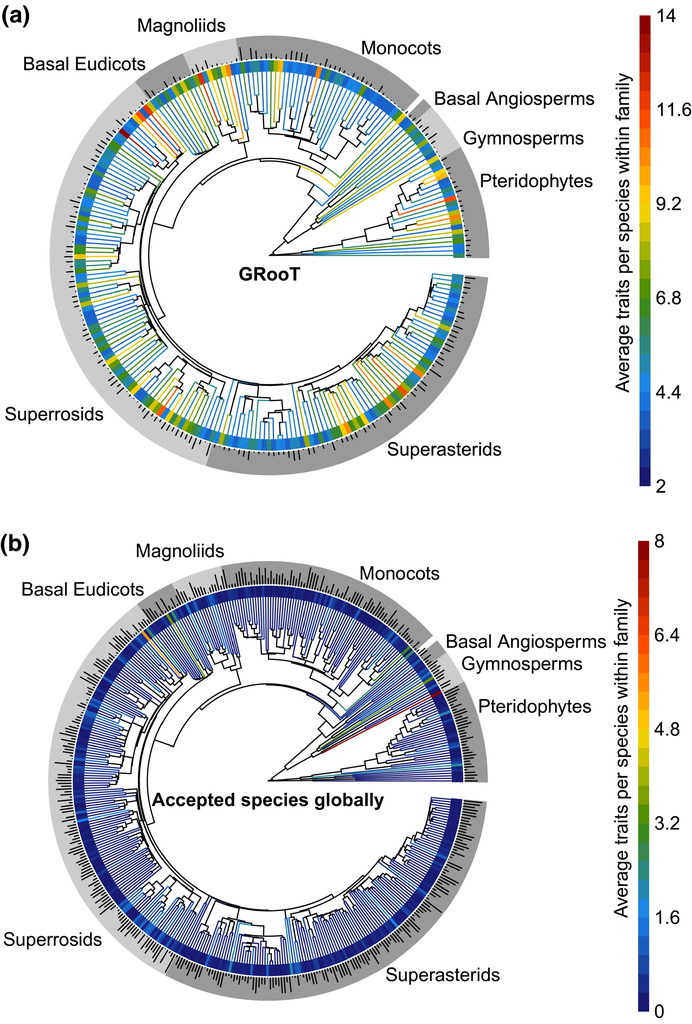

**FIGURE 2**

Phylogenetic coverage of root traits in Global Root Trait (GRooT). Panel (a) shows the average distribution of root traits per species in GRooT across the phylogeny (*n* = 6,214 species across *n* = 254 families) and panel (b) shows GRooT phylogenetic coverage based on the accepted species by The Plant List (*n* = 316,110 species across *n* = 442 families). Tip and inner ring color depict mean number of traits per species in a family while dark blue colour indicates families with lower number of traits per species. The outer ring represents major clades of vascular plants and the bars in this ring represent the family size (proportional to the logarithm base 10) either based on the number of species per family included in GRooT or the number of accepted species per family globally (Panel a and b, respectively).

## 4 DISCUSSION

GRooT is a uniquely important step towards the inclusion of root traits in large‐scale comparative studies and global models by integrating expert knowledge, data mobilization, standardization, curation and open accessibility. In terms of geo‐referenced data from field studies, GRooT has highest coverage in North America, Europe and Asia, especially for chemical and morphological traits, reflecting the capability for large‐scale studies in these regions. In terms of phylogenetic coverage, data in GRooT include the major clades of vascular plants with, on average, four traits included per species. Thereby, phylogenetic coverage in GRooT provides the possibility of using the data in large‐scale phylogenetic studies, such as analyses of trait conservatism (Averill et al., 2019; Valverde‐Barrantes et al., 2017) or assessments of trait relationships and trade‐offs across the phylogeny.

GRooT can be used for (but is not restricted to) studying macroecological and functional biogeography (Violle et al., 2014), assessing global belowground trait–environmental relationships as known from aboveground approaches (Bruelheide et al., 2018), and detecting fundamental ecological patterns, such as the root economic space (Bergmann et al., 2020) or trade‐offs and coordination among organs in the plant economic spectrum (Freschet et al., 2010). Furthermore, GRooT facilitates the integration of root traits into studies of related scientific disciplines, such as soil science and agronomy (Martin & Isaac, 2018; Wood et al., 2015). The completion of this standardized, curated and publicly available database provides immediate benefit to the research community from ready‐to‐use data (Gallagher et al., 2020) and provides additional direction, helping experts to identify gaps that need to be filled to increase completeness of global root trait data.

## ACKNOWLEDGMENTS

This initiative was possible owing to the support of the Synthesis Centre (sDiv) of the German Centre for Integrative Biodiversity Research (iDiv) Halle‐Jena‐Leipzig (DFG FZT 118) in the framework of the sRoot working group. We are grateful to all data contributors and to numerous assistants, technicians and students, who made it possible to have these hard‐earned, valuable data in the first place. We thank Owen Atkin, F. Stuart Chapin III, Brian Enquist, Thomas Hickler, Belinda Medlyn, Quentin Read, Michael White and Christian Wirth for contributing data, Jitka Klimesová for contributing data and providing comments on an earlier version of the manuscript, and A. Shafer Powell for assistance with FRED user guidance and data. We acknowledge the ECOCRAFT data contributors: Ana Rey, Craig Barton, Gail Jackson, Bernard Saugier, Franz Badeck, Eric Dufrêne, Rodolphe Liozon, Dieter Overdieck, Manfred Forstreuter, Joern Strassemeyer, Andrew Friend, Maureen Murray, Giuseppe Scarascia‐Mugnozza, Giorgio Matteuci, Paolo de Angelis, Mark Broadmeadow, Tim Randle, Eric Laitat, Bruno Portier, Bruno Chermanne, Reinhart Ceulemans, David de Pury, Ewa Jach, Ivan Janssens, Sune Linder, Johan Bergh, Sabine Philippot, Peter Roberntz, Jan Stockfors, Seppo Kellomaki, Kaisa Laitinen, Kaiyun Wang, Michal Marek and Breta Regner. Colleen M. Iversen and the Fine‐Root Ecology Database (FRED) are supported by the Biological and Environmental Research program in the Department of Energy’s Office of Science, and Joana Bergmann was supported by DFG grants RU‐1815/20‐1 and RI 1815/22‐1. Nathaly R. Guerrero‐Ramírez thanks the Dorothea Schlözer Postdoctoral Programme of the Georg‐August‐Universität Goettingen for their support; Nadejda A. Soudzilovskaia thanks vidi grant 016.161.318 issued by the Netherlands Organization for Scientific Research; and Vladimir G. Onipchenko thanks RSF for financial support (#16‐14‐10208). The study has been supported by the TRY initiative on plant traits ([http://www.try‐db.org](http://www.try-db.org/)). The TRY initiative and database are hosted, developed and maintained at the Max Planck Institute for Biogeochemistry, Jena, Germany. TRY is currently supported by DIVERSITAS/Future Earth and the German Centre for Integrative Biodiversity Research (iDiv) Halle‐Jena‐Leipzig. Open access funding enabled and organized by Projekt DEAL.

## APPENDIX 1

TABLE A1. Datasets included in GRooT from TRY

| Dataset ID | Datasets | References |
| --- | --- | --- |
| 328 | Root Traits of Grassland Species | Smith et al. (2014) |
| 162 | Mycorrhizal Intensity Database Across the Former Soviet Union | Akhmetzhanova et al. (2012) |
| 97 | Plant Physiology Database | Atkin et al. (1999); Loveys et al. (2003) |
| 292 | TOPIC (Traits of Plants in Canada) | Aubin et al. (2012) |
| 159 | Traits of US Desert Woody Plant Species | Butterfield and Briggs (2011) |
| 354 | Cedar Creek prairie plants (leaf, seed, dispersule, height, plant, root) | Catford et al. (2019; & unpublished) |
| 73 | Tundra Plant Traits Database | Unpublished |
| 72 | Sheffield & Spain Woody Database | Cornelissen et al. (2003) |
| 10 | Roots of the World (ROW) Database | Craine et al. (2005) |
| 130 | Global 15N Database | Craine et al. (2009) |
| 167 | Leaf N‐Retention Database | de Vries and Bardgett (2016) |
| 108 | The DIRECT Plant Trait Database | Everwand et al. (2014); Fry et al. (2014) |
| 265 | Saskatchewan Plant Trait Database | Guy et al. (2012) |
| 115 | Herbaceous Traits from the Öland Island Database | Hickler (1999) |
| 129 | The Americas N & P Database | Kerkhoff et al. (2006) |
| 191 | Baccara—Plant traits of European Forests | Unpublished |
| 12 | ECOCRAFT | Medlyn et al. (1999) |
| 200 | Altitudinal Vicariants Spain | Milla and Reich (2011) |
| 316 | Element content of plant organs of halophytic species NW Germany | Minden and Kleyer (2014) |
| 111 | Leaf and Whole‐Plant Traits Database: Hydraulic and Gas Exchange Physiology, Anatomy, Venation Structure | Sack (2004); Nakahashi et al. (2005); Quero et al. (2008) |
| 91 | Catalonian Mediterranean Forest Trait Database | Ogaya and Peñuelas (2003) |
| 27 | BROT Plant Trait Database | Paula et al. (2009); Tavşanoğlu and Pausas (2018) |
| 131 | Catalonian Mediterranean Shrubland Trait Database | Unpublished |
| 323 | Rocky Mountain Biological Laboratory WSR/gradient plant traits | Unpublished |
| 96 | Global Respiration Database | Reich et al. (2008) |
| 376 | Biomass allocation in beech and spruce seedlings | Schall et al. (2012) |
| 50 | Leaf and Whole Plant Traits Database | Shipley and Vu (2002) |
| 313 | Wood carbon content Database | Thomas and Martin (2012) |
| 163 | Plant Traits for Grassland Species (Konza Prairie, Kansas, USA) | Tucker et al. (2011) |
| 216 | Traits for Common Grasses and Herbs in Spain | Unpublished |
| 56 | Wetland Dunes Database | van Bodegom et al. (2005) |
| 330 | Traits of Ukraine native and invasive plant species | Unpublished |
| 79 | BIOME‐BGC Parameterization Database | White et al. (2000) |
| 68 | The Functional Ecology of Trees (FET) Database—Jena | Wirth and Lichstein (2009) |
| 221 | Leaf Economic Traits Across Varying Environmental Conditions | Wright and Sutton‐Grier (2012) |
| 247 | Traits of Halohytic Species in North‐West‐Germany | Minden et al. (2012) |
| 329 | Plant traits from alpine plants on Mt. Malaya Khatipata | Soudzilovskaia et al. (2013) |
| 243 | CLO‐PLA: A Database of Clonal Growth in Plants | Klimešová and Bello (2009); Klimešová et al. (2017, 2019) |

**REFERENCES**

Akhmetzhanova, A. A., Soudzilovskaia, N. A., Onipchenko, V. G., Cornwell, W. K., Agafonov, V. A., Selivanov, I. A. & Cornelissen, J. H. C. (2012). A rediscovered treasure: Mycorrhizal intensity database for 3000 vascular plant species across the former Soviet Union. *Ecology*, *93*, 689–690.

Atkin, O. K., Schortemeyer, M., McFarlane, N. & Evans, J. R. (1999). The response of fast‐ and slow‐growing acacia species to elevated atmospheric CO₂: An analysis of the underlying components of relative growth rate. *Oecologia*, *120*, 544–554.

Aubin, I., Messier, C., Gachet, S., Lawrence, K., McKenney, D., Arseneault, A., … Ricard, J. P. (2012). *TOPIC–Traits of plants in Canada*. Sault Ste. Marie, ON, Canada: Natural Resources Canada, Canadian Forest Service. Retrieved from http://cfs.cloud.nrcan.gc.ca/ctn/topic.php?lang=e

Butterfield, B. J. & Briggs, J. M. (2011). Regeneration niche differentiates functional strategies of desert woody plant species. *Oecologia*, *165*, 477–487.

Catford, J. A., Smith, A. L., Wragg, P. D., Clark, A. T., Kosmala, M., Cavender‐Bares, J., … Tilman, D. (2019). Traits linked with species invasiveness and community invasibility vary with time, stage and indicator of invasion in a long‐term grassland experiment. *Ecology Letters*, *22*, 593–604.

Cornelissen, J. H. C., Cerabolini, B., Castro‐Díez, P., Villar‐Salvador, P., Montserrat‐Martí, G., Puyravaud, J. P., … Aerts, R. (2003). Functional traits of woody plants: Correspondence of species rankings between field adults and laboratory‐grown seedlings? *Journal of Vegetation Science*, *14*, 311–322.

Craine, J. M., Elmore, A. J., Aidar, M. P. M., Bustamante, M., Dawson, T. E., Hobbie, E. A., … Wright, I. J. (2009). Global patterns of foliar nitrogen isotopes and their relationships with climate, mycorrhizal fungi, foliar nutrient concentrations, and nitrogen availability. *New Phytologist*, *183*, 980–992.

Craine, J. M., Lee, W. G., Bond, W. J., Williams, R. J. & Johnson, L. C. (2005). Environmental constraints on a global relationship among leaf and root traits of grasses. *Ecology*, *86*, 12–19.

de Vries, F. T. & Bardgett, R. D. (2016). Plant community controls on short‐term ecosystem nitrogen retention. *New Phytologist*, *210*, 861–874.

Everwand, G., Fry, E. L., Eggers, T. & Manning, P. (2014). Seasonal variation in the capacity for plant trait measures to predict grassland carbon and water fluxes. *Ecosystems*, *17*, 1095–1108.

Fry, E. L., Power, S. A. & Manning, P. (2014). Trait‐based classification and manipulation of plant functional groups for biodiversity–ecosystem function experiments. *Journal of Vegetation Science*, *25*, 248–261.

Guy, A. L., Mischkolz, J. M. & Lamb, E. G. (2012). Limited effects of simulated acidic deposition on seedling survivorship and root morphology of endemic plant taxa of the Athabasca Sand Dunes in well‐watered greenhouse trials. *Botany*, *91*, 176–181.

Hickler, T. (1999). *Plant functional types and community characteristics along environmental gradients on Öland’s Great Alvar (Sweden)*. Lund, Sweden: University of Lund.

Kerkhoff, A. J., Fagan, W. F., Elser, J. J. & Enquist, B. J. (2006). Phylogenetic and growth form variation in the scaling of nitrogen and phosphorus in the seed plants. *The American Naturalist*, *168*, E103–E122.

Klimešová, J. & Bello, F. D. (2009). CLO‐PLA: The database of clonal and bud bank traits of Central European flora. *Journal of Vegetation Science*, *20*, 511–516.

Klimešová, J., Danihelka, J., Chrtek, J., de Bello, F. & Herben, T. (2017). CLO‐PLA: A database of clonal and bud‐bank traits of the Central European flora. *Ecology*, *98*, 1179–1179.

Klimešová, J., Martínková, J., Pausas, J. G., de Moraes, M. G., Herben, T., Yu, F.‐H., … Ottaviani, G. (2019). Handbook of standardized protocols for collecting plant modularity traits. *Perspectives in Plant Ecology, Evolution and Systematics*, *40*, 125485.

Loveys, B. R., Atkinson, L. J., Sherlock, D. J., Roberts, R. L., Fitter, A. H. & Atkin, O. K. (2003). Thermal acclimation of leaf and root respiration: An investigation comparing inherently fast‐ and slow‐growing plant species. *Global Change Biology*, *9*, 895–910.

Medlyn, B. E., Badeck, F.‐W., Pury, D. G. G. D., Barton, C. V. M., Broadmeadow, M., Ceulemans, R., … Jstbid, P. G. (1999). Effects of elevated [CO<sub>2</sub>] on photosynthesis in European forest species: A meta‐analysis of model parameters. *Plant, Cell & Environment*, *22*, 1475–1495.

Milla, R. & Reich, P. B. (2011). Multi‐trait interactions, not phylogeny, fine‐tune leaf size reduction with increasing altitude. *Annals of Botany*, *107*, 455–465.

Minden, V., Andratschke, S., Spalke, J., Timmermann, H. & Kleyer, M. (2012). Plant trait–environment relationships in salt marshes: Deviations from predictions by ecological concepts. *Perspectives in Plant Ecology, Evolution and Systematics*, *14*, 183–192.

Minden, V. & Kleyer, M. (2014). Internal and external regulation of plant organ stoichiometry. *Plant Biology*, *16*, 897–907.

Nakahashi, C. D., Frole, K. & Sack, L. (2005). Bacterial leaf nodule symbiosis in *Ardisia* (Myrsinaceae): Does it contribute to seedling growth capacity? *Plant Biology*, *7*, 495–500.

Ogaya, R. & Peñuelas, J. (2003). Comparative field study of *Quercus ilex* and *Phillyrea latifolia*: Photosynthetic response to experimental drought conditions. *Environmental and Experimental Botany*, *50*, 137–148.

Paula, S., Arianoutsou, M., Kazanis, D., Tavsanoglu, Ç., Lloret, F., Buhk, C., … Pausas, J. G. (2009). Fire‐related traits for plant species of the Mediterranean Basin. *Ecology*, *90*, 1420–1420.

Quero, J. L., Villar, R., Marañón, T., Zamora, R., Vega, D. & Sack, L. (2008). Relating leaf photosynthetic rate to whole‐plant growth: Drought and shade effects on seedlings of four *Quercus* species. *Functional Plant Biology*, *35*, 725–737.

Reich, P. B., Tjoelker, M. G., Pregitzer, K. S., Wright, I. J., Oleksyn, J. & Machado, J.‐L. (2008). Scaling of respiration to nitrogen in leaves, stems and roots of higher land plants. *Ecology Letters*, *11*, 793–801.

Sack, L. (2004). Responses of temperate woody seedlings to shade and drought: Do trade‐offs limit potential niche differentiation? *Oikos*, *107*, 110–127.

Schall, P., Lödige, C., Beck, M. & Ammer, C. (2012). Biomass allocation to roots and shoots is more sensitive to shade and drought in European beech than in Norway spruce seedlings. *Forest Ecology and Management*, *266*, 246–253.

Shipley, B. & Vu, T.‐T. (2002). Dry matter content as a measure of dry matter concentration in plants and their parts. *New Phytologist*, *153*, 359–364.

Smith, S. W., Woodin, S. J., Pakeman, R. J., Johnson, D. & van der Wal, R. (2014). Root traits predict decomposition across a landscape‐scale grazing experiment. *New Phytologist*, *203*, 851–862.

Soudzilovskaia, N. A., Elumeeva, T. G., Onipchenko, V. G., Shidakov, I. I., Salpagarova, F. S., Khubiev, A. B., … Cornelissen, J. H. C. (2013). Functional traits predict relationship between plant abundance dynamic and long‐term climate warming. *Proceedings of the National Academy of Sciences USA*, *110*, 18180–18184.

Tavşanoğlu, Ç. & Pausas, J. G. (2018). A functional trait database for Mediterranean Basin plants. *Scientific Data*, *5*, 1–18.

Thomas, S. C. & Martin, A. R. (2012). Data from: Carbon content of tree tissues: A synthesis. *Dryad Digital Repository*. https://doi.org/10.5061/dryad.69sg2

Tucker, S. S., Craine, J. M. & Nippert, J. B. (2011). Physiological drought tolerance and the structuring of tallgrass prairie assemblages. *Ecosphere*, *2*, 1–19.

van Bodegom, P. M., de Kanter, M. & Aerts, C. B. R. (2005). Radial oxygen loss, a plastic property of dune slack plant species. *Plant and Soil*, *271*, 351–364.

White, M. A., Thornton, P. E., Running, S. W. & Nemani, R. R. (2000). Parameterization and sensitivity analysis of the BIOME–BGC terrestrial ecosystem model: Net primary production controls. *Earth Interactions*, *4*, 1–85.

Wirth, C. & Lichstein, J. W. (2009). *The imprint of species turnover on old‐growth forest carbon balances*—*Insights from a trait‐based model of forest dynamics*. In C. Wirth, G. Gleixner, & M. Heimann (Eds.), *Old‐growth forests: Function, fate and value* *ecological studies* (pp. 81–113). Berlin, Heidelberg: Springer.

Wright, J. P. & Sutton‐Grier, A. (2012). Does the leaf economic spectrum hold within local species pools across varying environmental conditions? *Functional Ecology*, *26*, 1390–1398.

## BIOSKETCH

The Global Root Trait Research Team is a group of root ecologists interested in contributing to the inclusion of root traits in large‐scale comparative studies and global models by offering standardized and publicly curated data of key root traits. The team built GRooT during two synthesis workshops on root traits (sRoot working group) and with the help of external researchers. The team has also developed interconnections with other databases, creating innovative linkages and facilitating the use of complementary information among databases. The goal is to provide accessible information to overcome the conceptual and methodological roadblocks limiting the use of root traits by a wide community of ecologists and biogeographers assessing topics such as global belowground trait–environmental relationships, detecting ecological patterns such as the root economic space or trade‐offs and coordination among organs in the plant economic spectrum.

[figure not shown]

Online Version of Record before inclusion in an issue

### Details

- © 2020 The Authors. Global Ecology and Biogeography published by John Wiley & Sons Ltd

  This is an open access article under the terms of the [Creative Commons Attribution](http://creativecommons.org/licenses/by/4.0/) License, which permits use, distribution and reproduction in any medium, provided the original work is properly cited.

[figure not shown]

### Keywords

  - [Belowground ecology](https://onlinelibrary.wiley.com/action/doSearch?field1=Keyword&text1=Belowground%20ecology)
  - [functional biogeography](https://onlinelibrary.wiley.com/action/doSearch?field1=Keyword&text1=functional%20biogeography)
  - [macroecological studies](https://onlinelibrary.wiley.com/action/doSearch?field1=Keyword&text1=macroecological%20studies)
  - [plant form and function](https://onlinelibrary.wiley.com/action/doSearch?field1=Keyword&text1=plant%20form%20and%20function)
  - [publicly‐available database](https://onlinelibrary.wiley.com/action/doSearch?field1=Keyword&text1=publicly%E2%80%90available%20database)
  - [root traits](https://onlinelibrary.wiley.com/action/doSearch?field1=Keyword&text1=root%20traits)

### Funding Information

  - Netherlands Organization for Scientific Research. Grant Number: vidi 016.161.318
  - Deutsche Forschungsgemeinschaft. Grant Numbers: FZT 118, RI 1815/22‐1, RU‐1815/20‐1
  - Robert Schalkenbach Foundation. Grant Number: #16‐14‐10208
  - Department of Energy's Office of Science

### Publication History

  - Version of Record online: 09 September 2020
  - Manuscript accepted: 28 July 2020
  - Manuscript revised: 08 June 2020
  - Manuscript received: 15 January 2020